# Problem 1

We consider two step Binomial model with $N=2$, $\Omega = \{ H,T \}$, $u = 2$ (goes up), $d = 1/2$ (goes down) and initial asset price at time zero $X_y(0) = 4$.

At time 1 the price is either at $X_y(1,H) = u \cdot X_y(0)$ or at $X_y(1,T) = d \cdot X_y(0)$. By generalizing the prior property we obtain the following tree-representation of the development of asset price $X_y(t, \cdot)$ at times $t = \{0,1,2\}$.

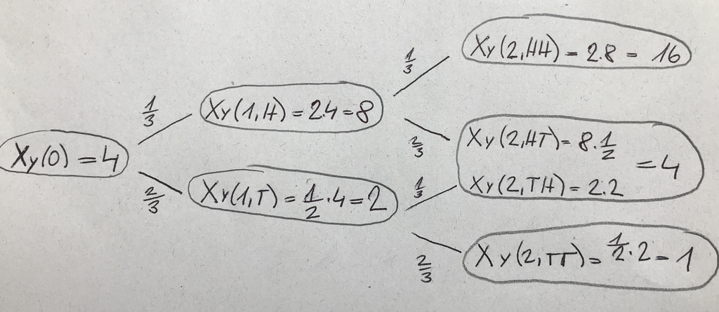

```python
# development of asset price X_y(t,.) at times t = {0,1,2}
from IPython.display import Image
Image("dev_x.jpg")
```

Now let us calculate the probability measures $\mathbb{P^y}(H)$ and $\mathbb{P^y}(T)$.

$$ \begin{aligned} X_y(0) &= \mathbb{E^y} [X_y(1)] = \mathbb{P^y}(H) \cdot u \cdot X_y(0) + (1 - \mathbb{P^y}(H)) \cdot d \cdot X_y(0) \\ 1 &= \mathbb{P^y}(H) \cdot u + (1 - \mathbb{P^y}(H)) \cdot d \\ 1 - d &= \mathbb{P^y}(H) \cdot (u-d). \end{aligned} $$

from which we get the following representations:

$$ \begin{aligned} \mathbb{P^y}(H) &= \frac{1-d}{u-d} = \frac{1-1/2}{2-1/2} = 1/3, \\ \mathbb{P^y}(T) &= 1 - \mathbb{P^y}(H) = \frac{2-1}{2-1/2} = 2/3. \end{aligned} $$

To compute the price of a contract with pay-off given by $V(2) = \mathbb{1}(X_Y(2)\neq 4) \cdot Y(2)$ using Y as a reference asset, we use the following formula $$ \begin{align} V_y(0) = \mathbb{E^y} [V_y(1)] = V_y(1,H) \cdot \mathbb{P^y}(H) + V_y(1,T) \cdot \mathbb{P^y}(T), \end{align} $$ which can be again further generalised for times $t = \{0,1,2\}$. The resulting tree-representation of the development of prices $V_y(t, \cdot)$ at times $t = \{0,1,2\}$ can be seen in the image below.

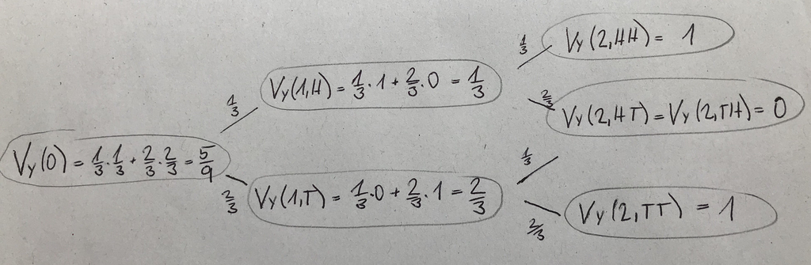

```python
# development of price V_y(t,.) at times t = {0,1,2}
Image("dev_v.jpg")
```

We have (for portfolio P) $$ \begin{aligned} P_y(1,H) &= \Delta^x(0) \cdot X_y(1,H) + \Delta^y(0) = V_y(1,H) \\ P_y(1,T) &= \Delta^x(0) \cdot X_y(1,T) + \Delta^y(0) = V_y(1,T) \\ V_y(1,H) - V_y(1,T) &= \Delta^x(0) \cdot X_y(1,H) - \Delta^x(0) \cdot X_y(1,T) + \Delta^y(0) - \Delta^y(0) \\ V_y(1,H) - V_y(1,T) &= \Delta^x(0) \cdot ( X_y(1,H) - X_y(1,T) ) \\ \Delta^x(0) &= \frac{V_y(1,H) - V_y(1,T)}{ X_y(1,H) - X_y(1,T)} = \dfrac{1/3-2/3}{8-2} = \dfrac{-1}{18}. \end{aligned} $$

# Problem 2

First let us denote the conditional probability $\mathbb{P^y}[(L \leq X_Y(T) \leq U)| X_Y(t) = x]$ as $\mathbb{P_t^y}[(L \leq X_Y(T) \leq U)]$.

Event defined as $\{ L \leq X_y(T) \leq U \}$ for some $L < U$ can be further modified as follows:

$$ \begin{aligned} L &\leq X_y(t) \cdot \exp{ \{ \sigma \cdot \left( W^y(T) - W^y(t) \right) - 1/2 \cdot \sigma^2 \cdot (T-t) \} } &\leq U \\ \log \frac{L}{X_y(t)} &\leq \sigma \cdot \left( W^y(T) - W^y(t) \right) - 1/2 \cdot \sigma^2 \cdot (T-t) &\leq \log \frac{U}{X_y(t)} \\ \log \frac{L}{X_y(t)} + 1/2 \cdot \sigma^2 \cdot (T-t)&\leq \sigma \cdot \left( W^y(T) - W^y(t) \right) &\leq \log \frac{U}{X_y(t)} + 1/2 \cdot \sigma^2 \cdot (T-t) \\ \frac{1}{\sigma} \cdot \log \frac{L}{X_y(t)} + 1/2 \cdot \sigma \cdot (T-t)&\leq W^y(T) - W^y(t) &\leq \frac{1}{\sigma} \cdot \log \frac{U}{X_y(t)} + 1/2 \cdot \sigma \cdot (T-t) \\ \frac{1}{\sigma \sqrt{ T-t}} \cdot \log \frac{L}{X_y(t)} + 1/2 \cdot \sigma \cdot \sqrt{ T-t} &\leq \frac{ W^y(T) - W^y(t) )}{\sqrt{ T-t}} &\leq \frac{1}{\sigma \sqrt{ T-t}} \cdot \log \frac{U}{X_y(t)} + 1/2 \cdot \sigma \cdot \sqrt{ T-t} \\ \frac{1}{\sigma \sqrt{ T-t}} \cdot \log \frac{X_y(t)}{U} - 1/2 \cdot \sigma \cdot \sqrt{ T-t} &\leq - \frac{ W^y(T) - W^y(t)}{\sqrt{ T-t}} &\leq \frac{1}{\sigma \sqrt{ T-t}} \cdot \log \frac{X_y(t)}{L} - 1/2 \cdot \sigma \cdot \sqrt{ T-t}. \end{aligned} $$

We denote the resulting bounds in accordance with the lecture notes notation as $$ d_{-}(L) =\frac{1}{\sigma \sqrt{ T-t}} \cdot \log \frac{X_y(t)}{L} - 1/2 \cdot \sigma \cdot \sqrt{ T-t},\\ d_{-}(U) =\frac{1}{\sigma \sqrt{ T-t}} \cdot \log \frac{X_y(t)}{U} - 1/2 \cdot \sigma \cdot \sqrt{ T-t}. $$

Since $- \frac{ W^y(T) - W^y(t)}{\sqrt{ T-t}}$ has a standard normal distribution $\mathcal{N}(0,1)$ under probability measure $\mathbb{P^y}$, the probability of the event $\{ L \leq X_y(T) \leq U \}$ for some $L < U$ is given as $$ \mathbb{P_t^y}[(L \leq X_Y(T) \leq U)] = \Phi(d_{-}(L)) - \Phi(d_{-}(U)), $$

where $\Phi(\cdot)$ is the cumulative distribution function of a standard normal variable $$ \Phi(x) = \int_{-\infty}^{x} \frac{1}{\sqrt{2 \pi}} \exp{ \frac{-u^2}{2}} du . $$

To find the corresponding hedging portfolio given by

$$ P(t) = \Delta^x(t) \cdot X(t) + \Delta^y(t) \cdot Y(t), $$

we derive the hedging positions $\Delta^x(t), \Delta^y(t)$.

$$ \begin{aligned} \Delta^x(t) &= u_x^y(t, X_y(t)) \\ &= \varphi(d_{-}(L)) \cdot \frac{1}{\sigma \sqrt{ T-t}} \cdot \frac{L}{X_y(t)} \cdot \frac{1}{L} - \varphi(d_{-}(U)) \cdot \frac{1}{\sigma \sqrt{ T-t}} \cdot \frac{U}{X_y(t)} \cdot \frac{1}{U} \\ &= \frac{1}{X_y(t) \sigma \sqrt{ T-t}} \cdot (\varphi(d_{-}(L)) - \varphi(d_{-}(U)), \\ \\ \Delta^y(t) &= u^y(t, X_y(t)) - u_x^y(t, X_y(t)) \cdot X_y(t) \\ &= N(d_{-}(L)) - N(d_{-}(U)) - \frac{1}{\sigma \sqrt{ T-t}} \cdot (\varphi(d_{-}(L)) - \varphi(d_{-}(U)), \end{aligned} $$

where $\varphi(\cdot)$ is the probability density function of standard normal distribution $\mathcal{N}(0,1)$.

The partial differential equation for the price function $u^y(t,x)$ takes the following form $$ u_t^y(t, x) + \frac{1}{2} \sigma^2 x^2 u_{xx}^y(t, x) = 0, $$ known as Black–Scholes partial differential equations.

The partial derivations computed via software Mathematica are presented below: $$ \begin{aligned} u_t^y(t, x) &= \frac{\left(\text{sigma}^2 (t-T)-2 \log \left(\frac{x}{L}\right)\right) \exp \left(\frac{\left(2 \log \left(\frac{x}{L}\right)+\text{sigma}^2 (t-T)\right)^2}{8 \text{sigma}^2 (t-T)}\right)+\left(\text{sigma}^2 (T-t)+2 \log \left(\frac{x}{U}\right)\right) \exp \left(\frac{\left(\text{sigma}^2 (t-T)+2 \log \left(\frac{x}{U}\right)\right)^2}{8 \text{sigma}^2 (t-T)}\right)}{4 \sqrt{2 \pi } \text{sigma} (T-t)^{3/2}}, \\ u_{xx}^y(t, x) &= \frac{\left(2 \log \left(\frac{x}{L}\right)+\text{sigma}^2 (T-t)\right) \exp \left(\frac{\left(2 \log \left(\frac{x}{L}\right)+\text{sigma}^2 (t-T)\right)^2}{8 \text{sigma}^2 (t-T)}\right)+\left(\text{sigma}^2 (t-T)-2 \log \left(\frac{x}{U}\right)\right) \exp \left(\frac{\left(\text{sigma}^2 (t-T)+2 \log \left(\frac{x}{U}\right)\right)^2}{8 \text{sigma}^2 (t-T)}\right)}{2 \sqrt{2 \pi } \text{sigma}^3 x^2 (T-t)^{3/2}} . \end{aligned} $$

Substituing the derived results in the PDE above gives zero (again verified by Mathematica), therefore our solution satisfies PDE.

# Problem 3

In the following part of the assignment we are supposed to compute the $\mathbb{E}[X^2(T)]$ for the process defined as $$ dX(t) = \sqrt{X(t) (1 - X(t))} \cdot dW(t) . $$

In order to do se, we first apply the Ito formula for process $Y(t) = f(X(t))$ with $f(x) = x^2$. The corresponding derivatives are computed below: $$ f_{x} = 2x, \\ f_{xx} = 2. $$

$$ \begin{aligned} dY(t) = dX^2(t) &= f_x(X(t))\cdot dX(t) + \frac{1}{2}\cdot f_{xx}(X(t))\cdot (dX(t))^2 \\ &= 2X(t)\cdot dX(t) + \frac{1}{2}\cdot 2\cdot (dX(t))^2 \\ &= 2X(t)\cdot dX(t) + (dX(t))^2 \\ &= 2X(t) \cdot \sqrt{X(t) (1 - X(t))} \cdot dW(t) + X(t) (1 - X(t)) \cdot dt. \end{aligned} $$

In the last equality we have rewritten $(dX(t))^2$ as $(dX(t) )^2 = X(t) (1 - X(t)) \cdot (dW(t))^2 = X(t) (1 - X(t)) \cdot dt $, where we have used the fact that $ dW(t) \cdot dW(t) = dt$.

To compute $X^2(t)$ we now integrate the prior result: $$ \begin{aligned} X^2(t) &= \int_{0}^{t} 2X(s) \cdot \sqrt{X(s) (1 - X(s))} \cdot dW(s) + \int_{0}^{t} X(s) (1 - X(s)) \cdot ds, \end{aligned} $$ and continue by taking expectation of the result. $$ \begin{aligned} \mathbb{E}\left[X^2(t)\right] &= \mathbb{E}\left[ \int_{0}^{t} 2X(s) \cdot \sqrt{X(s) (1 - X(s))} \cdot dW(s) + \int_{0}^{t} X(s) (1 - X(s)) \cdot ds \right] \\ &= \mathbb{E}\left[ \int_{0}^{t} 2X(s) \cdot \sqrt{X(s) (1 - X(s))} \cdot dW(s) \right] + \mathbb{E}\left[ \int_{0}^{t} X(s) (1 - X(s)) \cdot ds \right] \\ &= \mathbb{E}\left[ \int_{0}^{t} X(s) (1 - X(s)) \cdot ds \right], \end{aligned} $$ using the fact that the first summand equals zero because it is a martingale.

Let us continue (using the martingale property of $X$ in second equality) $$ \begin{aligned} \mathbb{E}\left[X^2(t) - X^2(0)\right] &= \int_{0}^{t} \mathbb{E}\left[ X(s) - X^2(s) \right] \cdot ds \\ &= \int_{0}^{t} \mathbb{E}\left[ X(s) \right] - \mathbb{E}\left[ X^2(s) \right] \cdot ds \\ &= \int_{0}^{t} X(0) - \mathbb{E}\left[ X^2(s) \right] \cdot ds. \end{aligned} $$ Denoting $$ u(t) = \int_{0}^{t} \mathbb{E}\left[X^2(s) - X(s)\right] ds = \int_{0}^{t} \mathbb{E}\left[X^2(s)\right] - X(0) \cdot ds, $$ the last equality from above, according to the prior calcul, yields differential equation $$ u'(t) = -u(t), $$ with the following exponential solution $$ u(t) = C \cdot \exp^{-t}, \\ C = u(0). $$

Hence it holds that $$ \begin{aligned} u'(t) &= -u(t) \\ \mathbb{E}\left[X^2(t) - X^2(0)\right] &= -u(t) \\ &= - u(0) \cdot \exp^{-t} \\ \mathbb{E}\left[X^2(t)\right] &= \mathbb{E}\left[X^2(0)\right] - u(0) \cdot \exp^{-t} = - u(0) \cdot \exp^{-t} \end{aligned} $$

## Problem 4

```python
import numpy as np
np.seterr(divide='ignore', invalid='ignore')
import pandas as pd

import scipy.stats as sp
import matplotlib.pyplot as plt
```

## (a) Brownian motion & Stock price simulations

Simulate and plot Brownian increments, the corresponding Brownian motion and the resulting stock price.

```python
np.random.seed(42)

def time_grid(T,N):
    # T = time horizon, N = number of steps (T*250 for daily convention)
    dt = T/N # time step
    return np.arange(0,T + dt,dt) # time grid

def brownian_sim(T, N):
    # T = time horizon, N = number of steps (T*250 for daily convention)
    dt = T/N # time step
    white_noise = np.sqrt(dt) * np.random.normal(loc = 0, scale = 1.0, size = N)
    output = np.append(0, np.cumsum(white_noise, axis = 0))
    return white_noise, output

def stock_sim(S0, T, N, sigma):
    # S0 = initial stock price, T = time horizon, N = number of steps, sigma = volatility
    _ , brownian = brownian_sim(T,N) # time step, _ , brownian simulation
    time = time_grid(T, N) # time grid
    stock = S0 * np.exp(sigma * brownian -  (sigma**2 * time) / 2)
    return stock
```

```python
T = 2 # time horizon
N = T * 250 # number of steps
sigma = 0.2 # volatility
S0 = 100 # initial stock price
```

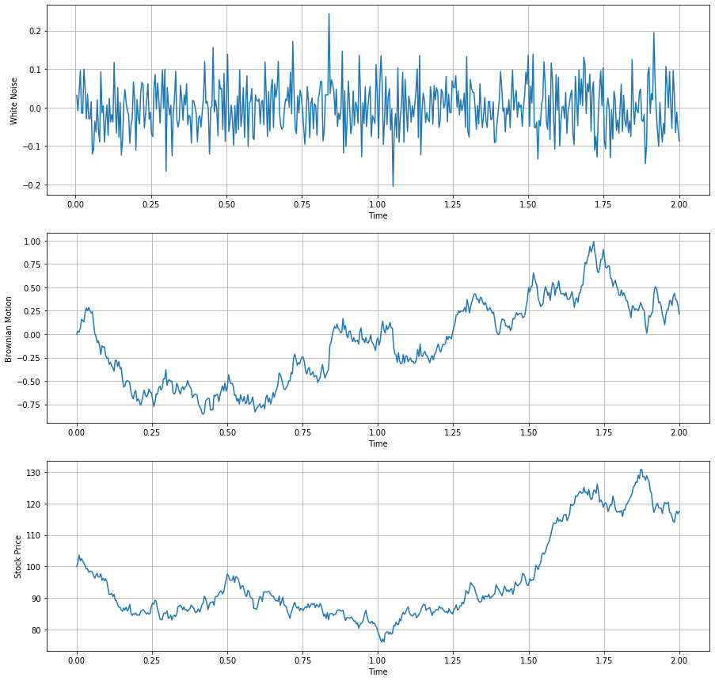

```python
# create timegrid
time = time_grid(T, N)
# generate simulations
white_noise, brownian = brownian_sim(T, N)
# simulate stock price
stock_price = stock_sim(S0, T, N, sigma)

# plot the results
fig, (ax1, ax2, ax3) = plt.subplots(3,1, figsize = (15,15))
ax1.plot(time[1:],white_noise)
ax1.grid()
ax1.set_xlabel('Time')
ax1.set_ylabel('White Noise')
ax2.plot(time,brownian)
ax2.grid()
ax2.set_xlabel('Time')
ax2.set_ylabel('Brownian Motion')
ax3.plot(time,stock_price)
ax3.grid()
ax3.set_xlabel('Time')
ax3.set_ylabel('Stock Price')
```

## (b) European Call Option

Write functions that computes the price of a European call option and the hedging position for this option. Then construct a hedging portfolio for this option using the data from a simulated path in the previous section.

```python
def d_plus(x, K, T, t, sigma):
    # x = stock,  K = strike price, T = time horizon, t = time, sigma = volatility
    denom = sigma * np.sqrt(T-t)
    return (np.log(x/K) + (sigma**2 / 2) * (T-t)) / denom

def d_minus(x, K, T, t, sigma):
    # x = stock,  K = strike price, T = time horizon, t = time, sigma = volatility
    denom = sigma * np.sqrt(T-t)
    return (np.log(x/K) - (sigma**2 / 2) * (T-t)) / denom

def eu_call_price(x, K, T, t, sigma):
    # x = stock,  K = strike price, T = time horizon, t = time, sigma = volatility
    d1 = d_plus(x,K,T,t,sigma)
    d2 = d_minus(x,K,T,t,sigma)
    return sp.norm.cdf(d1) * x - K * sp.norm.cdf(d2)

def eu_call_hedge_x(x, K, T, t, sigma):
    # x = stock,  K = strike price, T = time horizon, t = time, sigma = volatility
    d1 = d_plus(x,K,T,t,sigma)
    return sp.norm.cdf(d1)

def eu_call_hedge_y(x, K, T, t, sigma):
    # x = stock,  K = strike price, T = time horizon, t = time, sigma = volatility
    d1 = d_minus(x, K, T, t, sigma)
    return -K * sp.norm.cdf(d1)
```

```python
T = 2 # time horizon
N = T * 250 # number of steps
sigma = 0.2 # volatility
S0 = 100 # initial stock price
K = 50 # strike price
```

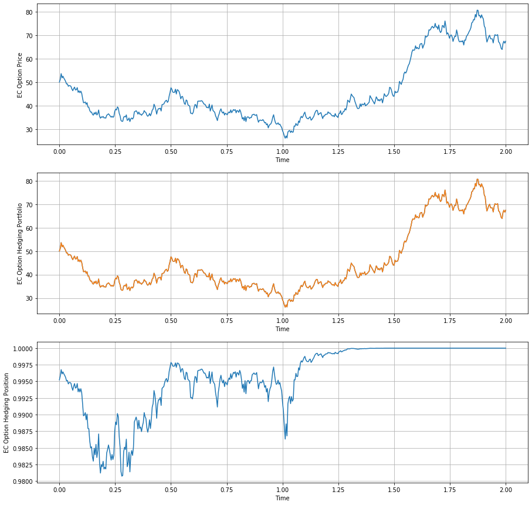

```python
# create time grid
time = time_grid(T, N)

# generate European Call Option price and hedging postion
euc_price = eu_call_price(stock_price, K, T, time, sigma)
hedge_position_x = eu_call_hedge_x(stock_price, K, T, time, sigma)

# construct a hedging portfolio for this option
portfolio = np.full(N + 1, euc_price[0], dtype=float)
for i in range(N):
    portfolio[i+1] = portfolio[i] + hedge_position_x[i] * (stock_price[i+1] - stock_price[i])

fig, (ax1, ax2, ax3) = plt.subplots(3,1, figsize = (15,15))
ax1.plot(time, euc_price)
ax1.grid()
ax1.set_xlabel('Time')
ax1.set_ylabel('EC Option Price')
ax2.plot(time,euc_price)
ax2.plot(time,portfolio)
ax2.grid()
ax2.set_xlabel('Time')
ax2.set_ylabel('EC Option Hedging Portfolio')
ax3.plot(time, hedge_position_x)
ax3.grid()
ax3.set_xlabel('Time')
ax3.set_ylabel('EC Option Hedging Position')
```

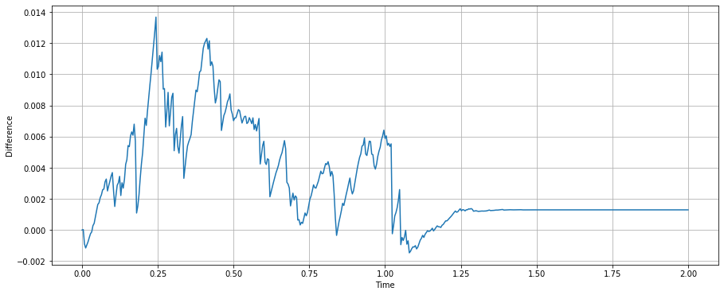

```python
# plot the difference between portfolio and euc_price
plt.figure(figsize=(15,6))
plt.plot(time, portfolio - euc_price)
plt.grid()
plt.xlabel('Time')
plt.ylabel('Difference')
plt.show()
```

## (c) European Call Option with Dividend and Interest Rate

Allow for a continuous dividend yield and continuous interest rate and use it on SP500 data.

```python
def stock_conversion(price, time, r, q):
    # r = interest rate, q = dividend yield
    return price * np.exp((r-q)*time)

def d_plus_rq(x,K,T,t,sigma,r,q):
    # x = stock,  K = strike price, T = time horizon, t = time, sigma = volatility, r = interest rate, q = dividend yield
    denom = sigma * np.sqrt(T-t)
    return (np.log(x/K) + ( (r-q) + sigma**2 / 2) * (T-t)) / denom

def d_minus_rq(x,K,T,t,sigma,r,q):
     # x = stock,  K = strike price, T = time horizon, t = time, sigma = volatility, r = interest rate, q = dividend yield
    denom = sigma * np.sqrt(T-t)
    return (np.log(x/K) + ( (r-q) - sigma**2 / 2) * (T-t)) / denom

def eu_call_price_rq(x,K,T,t,sigma,r,q):
    # x = stock,  K = strike price, T = time horizon, t = time, sigma = volatility, r = interest rate, q = dividend yield
    d1 = d_plus_rq(x,K,T,t,sigma,r,q)
    d2 = d_minus_rq(x,K,T,t,sigma,r,q)
    exp1 = np.exp(-q * (T-t))
    exp2 = np.exp(-r * (T-t))
    return exp1 * sp.norm.cdf(d1) * x - K * exp2 * sp.norm.cdf(d2)

def eu_call_hedge_rq_x(x,K,T,t,sigma,r,q):
    # x = stock,  K = strike price, T = time horizon, t = time, sigma = volatility, r = interest rate, q = dividend yield
    d1 = d_plus_rq(x,K,T,t,sigma,r,q)
    exp1 = np.exp(-q * (T-t))
    return exp1 * sp.norm.cdf(d1)

def eu_call_hedge_rq_y(x,K,T,t,sigma,r,q):
    # x = stock,  K = strike price, T = time horizon, t = time, sigma = volatility, r = interest rate, q = dividend yield
    d2 = d_minus_rq(x,K,T,t,sigma,r,q)
    exp2 = np.exp(-r * (T-t))
    return - K * exp2 * sp.norm.cdf(d2)
```

### SP500 data

```python
from pandas_datareader import data as wb
```

```python
symbol = '^GSPC'
data_source = 'yahoo'
start_date = '2019-01-01'
end_date = '2019-12-31'
strike_date =  '2019-01-01'

SP500 = wb.DataReader(symbol, data_source, start_date, end_date)["Adj Close"]
SP500
```

```
Date
2019-01-02    2510.030029
2019-01-03    2447.889893
2019-01-04    2531.939941
2019-01-07    2549.689941
2019-01-08    2574.409912
                 ...
2019-12-24    3223.379883
2019-12-26    3239.909912
2019-12-27    3240.020020
2019-12-30    3221.290039
2019-12-31    3230.780029
Name: Adj Close, Length: 252, dtype: float64
```

```python
start_date_18 = '2018-01-01'
end_date_18 = '2018-12-31'

SP500_2018 = wb.DataReader(symbol, data_source, start_date_18, end_date_18)["Adj Close"]

# estimate sigma
log_returns = np.diff(np.log(SP500_2018))
sigma_est = np.std(log_returns)
sigma_est
```

```
0.01075764260998323
```

```python
returns = np.diff(SP500_2018) / SP500_2018[0:250]
sigma_est_v2 = np.std(returns)
sigma_est_v2
```

```
0.010727948921664005
```

```python
T = 1 # time horizon
N = len(SP500_2018) # number of steps
dt = T / N # time step
r = 0.1 # interest rate
q = 0.2 # dividend yield
K = SP500[0] * np.exp( (r-q) * T) # strike price
```

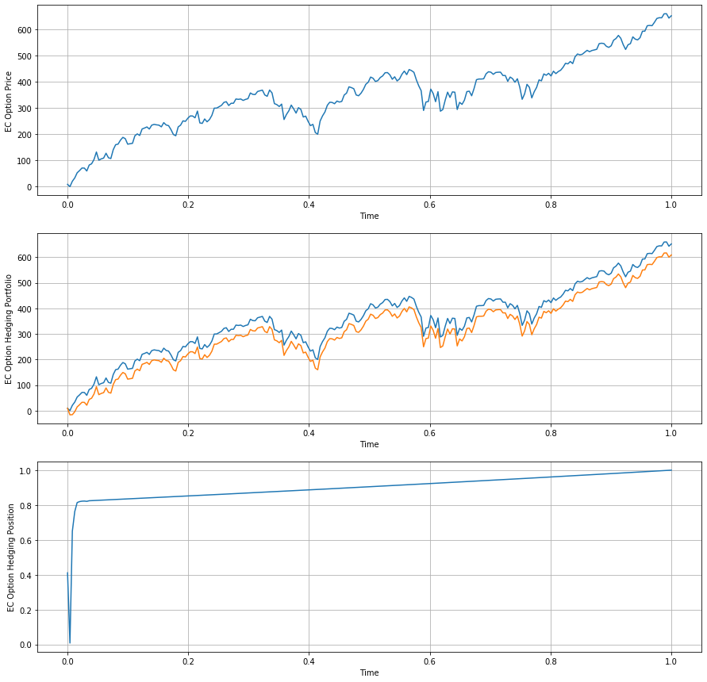

```python
# create time grid
time = time_grid(T, N)
# convert stock price
stock_price_div = stock_conversion(SP500, time, r, q)
# generate European Call Option price and hedging postion with IR and dividend
euc_price_div = eu_call_price_rq(stock_price_div, K, T, time, sigma_est, r, q)
euc_hedge_div_x = eu_call_hedge_rq_x(stock_price_div, K, T, time, sigma_est, r, q)

# construct a hedging portfolio for this option
portfolio_rq = np.full(N + 1, euc_price_div[0], dtype=float)
for i in range(N):
    portfolio_rq[i+1] = portfolio_rq[i] * (1 + r * dt) + euc_hedge_div_x[i] * (stock_price_div[i+1] - stock_price_div[i] * (1 + (r-q) * dt))

fig, (ax1, ax2, ax3) = plt.subplots(3,1, figsize = (15,15))
ax1.plot(time, euc_price_div)
ax1.grid()
ax1.set_xlabel('Time')
ax1.set_ylabel('EC Option Price')
ax2.plot(time, euc_price_div)
ax2.plot(time, portfolio_rq)
ax2.grid()
ax2.set_xlabel('Time')
ax2.set_ylabel('EC Option Hedging Portfolio')
ax3.plot(time, euc_hedge_div_x)
ax3.grid()
ax3.set_xlabel('Time')
ax3.set_ylabel('EC Option Hedging Position')
```

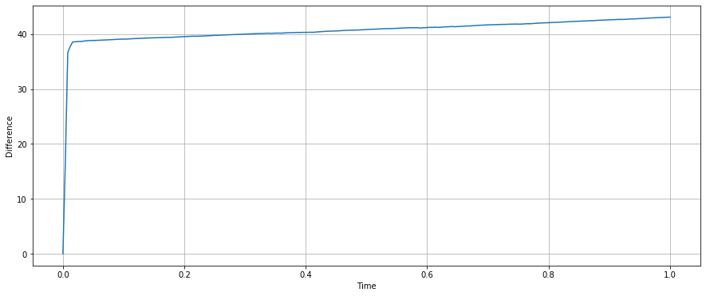

```python
# plot the difference between portfolio_rq and euc_price_div
plt.figure(figsize=(15,6))
plt.plot(time, euc_price_div - portfolio_rq)
plt.grid()
plt.xlabel('Time')
plt.ylabel('Difference')
plt.show()
```

## (d) Implemented solutions of Problem 2

Write the pricing and hedging functions for the solution in Problem 2.

```python
def contract_pricing(x, L, U, T, t, sigma):
    # x = stock,  L = lower bound, U = upper bound, T = time horizon, t = time, sigma = volatility
    dL = d_minus(x, L, T, t, sigma)
    dU = d_minus(x, U, T, t, sigma)
    return sp.norm.cdf(dL) - sp.norm.cdf(dU)

def hedge_delta_x(x, L, U, T, t, sigma):
    # x = stock,  L = lower bound, U = upper bound, T = time horizon, t = time, sigma = volatility
    dL = d_minus(x, L, T, t, sigma)
    dU = d_minus(x, U, T, t, sigma)
    denom = x * sigma * np.sqrt(T-t)
    return ( sp.norm.pdf(dL) - sp.norm.pdf(dU) ) / denom

def hedge_delta_y(x, L, U, T, t, sigma):
    # x = stock,  L = lower bound, U = upper bound, T = time horizon, t = time, sigma = volatility
    dL = d_minus(x, L, T, t, sigma)
    dU = d_minus(x, U, T, t, sigma)
    denom = sigma * np.sqrt(T-t)
    return  sp.norm.cdf(dL) - sp.norm.cdf(dU)  - ( sp.norm.pdf(dL) - sp.norm.pdf(dU) ) / denom
```

```python
T = 2 # time horizon#
N = T * 250 # number of steps
sigma = 0.1 # volatility
L = 100 # lower bound
U = 200 # upper bound
```

```python
# create time grid
time = time_grid(T, N)
```

### In The Money

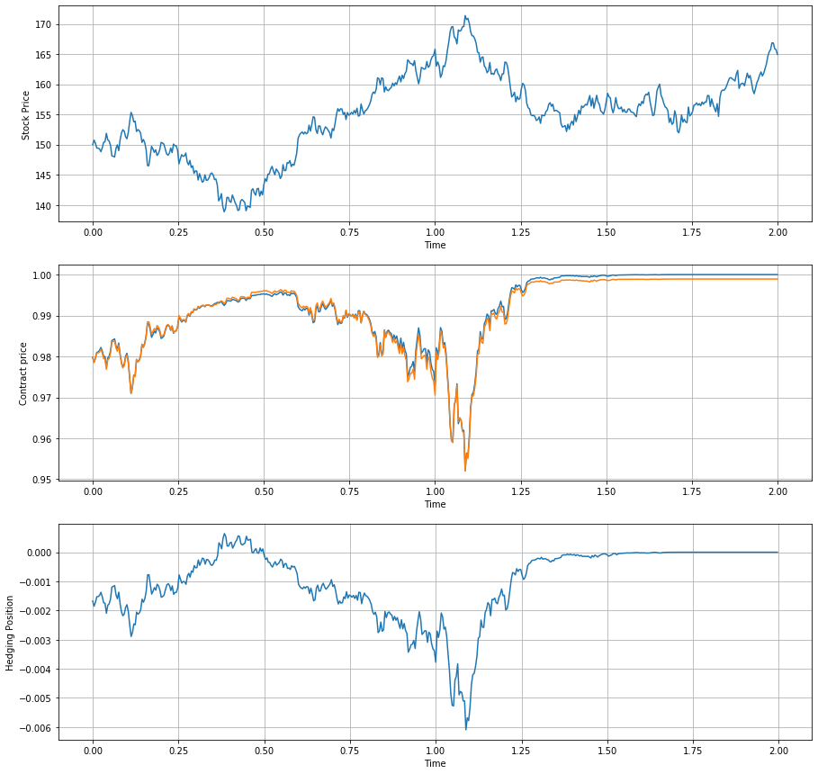

```python
# initial stock price
S0 = 150
# simulate stock price
stock_price_p2 = stock_sim(S0, T, N, sigma)

# generate contract price and hedging postion
contract_price = contract_pricing(stock_price_p2, L, U, T, time, sigma)
hedge_position_x_p2 = hedge_delta_x(stock_price_p2, L, U, T, time, sigma)

# construct a hedging portfolio for this contract
portfolio_p2 = np.full(N + 1, contract_price[0], dtype=float)
for i in range(N):
    portfolio_p2[i+1] = portfolio_p2[i] + hedge_position_x_p2[i] * (stock_price_p2[i+1] - stock_price_p2[i])

fig, (ax1, ax2, ax3) = plt.subplots(3,1, figsize = (15,15))
ax1.plot(time, stock_price_p2)
ax1.grid()
ax1.set_xlabel('Time')
ax1.set_ylabel('Stock Price')
ax2.plot(time, contract_price)
ax2.plot(time, portfolio_p2)
ax2.grid()
ax2.set_xlabel('Time')
ax2.set_ylabel('Contract price')
ax3.plot(time, hedge_position_x_p2)
ax3.grid()
ax3.set_xlabel('Time')
ax3.set_ylabel('Hedging Position')
```

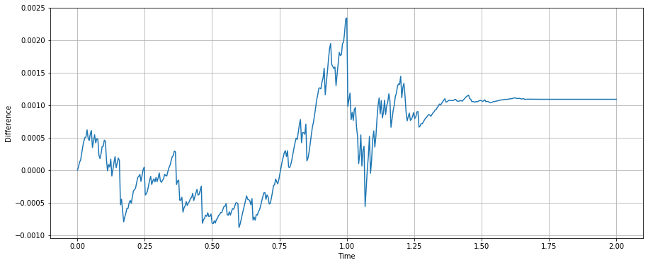

```python
# plot the difference between portfolio_p2 and contract_price
plt.figure(figsize=(15,6))
plt.plot(time, contract_price - portfolio_p2)
plt.grid()
plt.xlabel('Time')
plt.ylabel('Difference')
plt.show()
```

### Out Of The Money

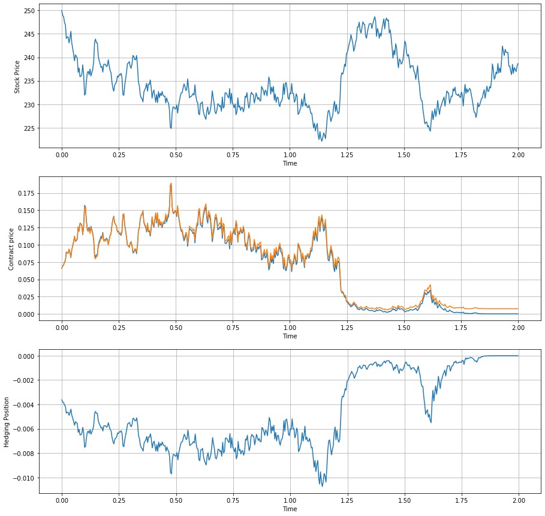

```python
# initial stock price
S0 = 250
# simulate stock price
stock_price_p2 = stock_sim(S0, T, N, sigma)

# generate contract price and hedging postion
contract_price = contract_pricing(stock_price_p2, L, U, T, time, sigma)
hedge_position_x_p2 = hedge_delta_x(stock_price_p2, L, U, T, time, sigma)

# construct a hedging portfolio for this option
portfolio_p2 = np.full(N + 1, contract_price[0], dtype=float)
for i in range(N):
    portfolio_p2[i+1] = portfolio_p2[i] + hedge_position_x_p2[i] * (stock_price_p2[i+1] - stock_price_p2[i])

fig, (ax1, ax2, ax3) = plt.subplots(3,1, figsize = (15,15))
ax1.plot(time, stock_price_p2)
ax1.grid()
ax1.set_xlabel('Time')
ax1.set_ylabel('Stock Price')
ax2.plot(time, contract_price)
ax2.plot(time, portfolio_p2)
ax2.grid()
ax2.set_xlabel('Time')
ax2.set_ylabel('Contract price')
ax3.plot(time, hedge_position_x_p2)
ax3.grid()
ax3.set_xlabel('Time')
ax3.set_ylabel('Hedging Position')
```

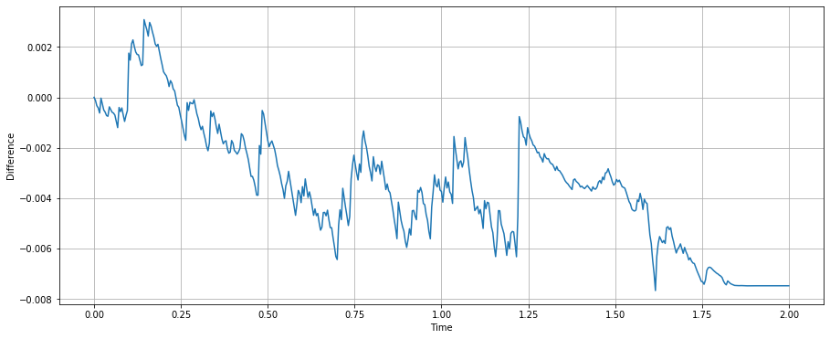

```python
# plot the difference between portfolio_p2 and contract_price
plt.figure(figsize=(15,6))
plt.plot(time, contract_price - portfolio_p2)
plt.grid()
plt.xlabel('Time')
plt.ylabel('Difference')
plt.show()
```